# IAM en Hospital El Cruce: captación territorial y priorización operativa

[figure not shown]

[figure not shown]

[figure not shown]

[figure not shown]

# Contextualización

### Alcance y contexto del análisis

#### Qué representa la tasa IAM-HEC

#### Objeto del análisis

Este tablero describe la distribución territorial de los casos de infarto agudo de miocardio (IAM) atendidos en el Hospital El Cruce (HEC), estandarizada por la población residente de cada radio censal. El outcome no representa incidencia poblacional total de IAM: integra la ocurrencia del evento y la probabilidad de acceso, derivación o captación por HEC.

$$Tasa\ IAM_{HEC}=\frac{Casos\ de\ IAM\ atendidos\ en\ HEC}{Población\
del\ radio}\times100.000$$

La unidad de análisis es el radio censal y las inferencias son ecológicas. Una tasa elevada puede reflejar mayor ocurrencia de IAM, mayor captación/derivación por HEC o una combinación de ambos procesos.

#### Datos integrados y cobertura

#### Fuentes territoriales utilizadas

El análisis integra casos agregados por residencia, población censal, nivel socioeconómico (NSE), Vulnerabilidad Sanitaria, accesibilidad y geometrías censales. Para el benchmark principal se utilizaron sólo predictores con cobertura completa: Vulnerabilidad Sanitaria, NSE, Tiempo medio a salud, distancia al HEC, coordenadas X/Y, PERSONAS y Total de hogares.

#### Decisión sobre datos faltantes

Las variables RENABAP y PHC/P_HCNBI22 quedaron fuera del análisis principal por su elevada proporción de datos faltantes. El modelo principal se ajustó sin imputación de covariables, de modo que la disponibilidad del outcome —y no la ausencia de predictores— determinara esencialmente el tamaño analítico.

#### Validación territorial

La generalización se evaluó mediante validación cruzada espacial externa de cinco folds. Se compararon Random Forest, XGBoost, SVM radial, GAM y BYM2 sobre particiones espaciales comunes. El GAM mostró el mejor desempeño para IAM total.

#### Especificación final

$$Tasa\ IAM_{HEC}=s(Hogares)+s(NSE)+s(Vulnerabilidad\ Sanitaria)+s(X,Y)$$
La superficie bidimensional `s(coord_x, coord_y)` rindió ligeramente mejor que una representación puramente radial por distancia al HEC y evitó la redundancia casi perfecta producida al incluir ambas representaciones espaciales simultáneamente.

#### Cómo debe utilizarse

La herramienta caracteriza el área de influencia/captación del HEC, permite reconocer patrones territoriales y ordenar radios para revisión operativa. La prioridad calculada es relativa al territorio analizado y **no representa riesgo cardiovascular individual**.

# Modelo GAM final

### Modelo, validación e interpretación

#### Radios modelados

887

#### R² medio CV espacial

0.298

#### RMSE medio CV

58.0

#### MAE medio CV

44.8

#### R² OOF agregado

0.236

Las métricas se obtienen a partir de predicciones fuera de muestra. El R² medio resume el comportamiento entre los cinco folds espaciales; el R² OOF se calcula sobre todas las predicciones concatenadas cuando cada radio estuvo fuera del entrenamiento.

#### Comparación de algoritmos

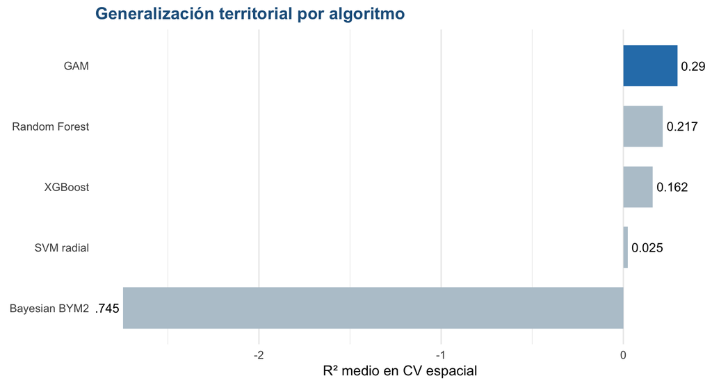

El GAM se destaca por presentar el mayor R² medio bajo validación espacial.

| Modelo | Escalado | RMSE medio | MAE medio | R² medio | SD R² |
| --- | --- | --- | --- | --- | --- |
| GAM | Scaled | 58.165 | 44.36 | 0.296 | 0.156 |
| Random Forest | Scaled | 61.551 | 48.828 | 0.217 | 0.12 |
| XGBoost | Scaled | 63.503 | 47.214 | 0.162 | 0.212 |
| SVM radial | Scaled | 68.58 | 41.472 | 0.025 | 0.162 |
| Bayesian BYM2 | Scaled | 131.341 | 116.587 | -2.745 | 1.076 |

#### Representación de la estructura espacial

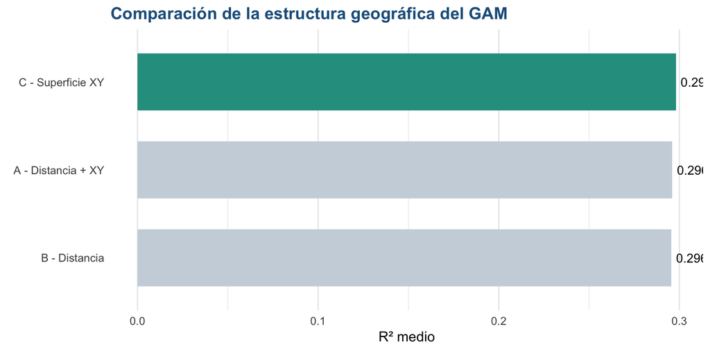

| Estructura espacial | RMSE | MAE | R² medio | R² mediano | R² OOF | Moran I | p Moran |
| --- | --- | --- | --- | --- | --- | --- | --- |
| C - Superficie XY | 57.996 | 44.849 | 0.298 | 0.235 | 0.236 | 0.04 | 0.033 |
| A - Distancia + XY | 58.172 | 44.353 | 0.296 | 0.232 | 0.236 | 0.039 | 0.034 |
| B - Distancia | 58.124 | 45.284 | 0.296 | 0.225 | 0.235 | 0.043 | 0.024 |

La superficie `s(coord_x, coord_y)` fue seleccionada porque mostró el mejor desempeño medio y evitó la concurvity casi perfecta observada cuando se incluyeron simultáneamente distancia al HEC y coordenadas.

#### Efectos parciales del GAM final

El modelo retuvo Total de hogares, NSE, Vulnerabilidad Sanitaria y una superficie geográfica bidimensional. Total de hogares presentó la mayor no linealidad; NSE mostró una asociación aproximadamente lineal positiva y Vulnerabilidad Sanitaria una asociación inversa ajustada. La superficie XY representa estructura geográfica que persiste después de ajustar por las covariables territoriales.

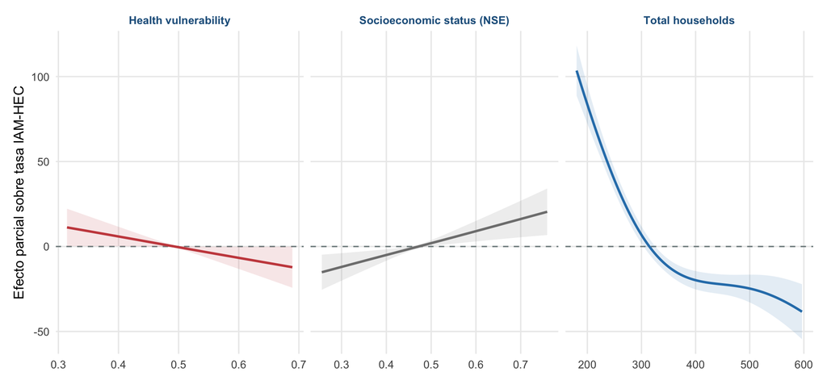

El Moran I residual se utiliza como diagnóstico de estructura espacial no explicada y no como métrica de precisión. La autocorrelación residual pequeña pero significativa sugiere que persisten determinantes territoriales no incluidos en el modelo.

# Priorización territorial

### Regla de decisión

**Crítica**Tasa GAM en el cuartil más alto y, además, hotspot residual HH o Vulnerabilidad Sanitaria alta/muy alta.

**Alta**Tasa GAM alta o muy alta sin criterio adicional de criticidad.

**Vigilancia**Tasa GAM media, límite superior aproximado del 95% en el cuartil más alto o incertidumbre de estimación muy alta.

**Baja**Radios que no cumplen los criterios anteriores.

**Lectura recomendada.** La prioridad combina magnitud modelada, incertidumbre, vulnerabilidad y estructura residual. Debe utilizarse como herramienta de selección de territorios para auditoría o planificación, no como clasificación etiológica ni como estimación de riesgo cardiovascular individual.

### Distribución actual

#### Crítica

72

#### Alta

371

#### Vigilancia

320

#### Baja

124

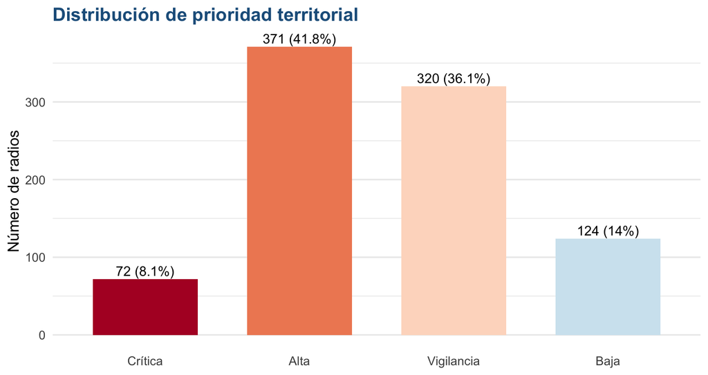

### Ranking de radios prioritarios

Se muestran los radios clasificados como **Crítica** o **Alta**, ordenados primero por prioridad y luego por tasa GAM predicha. La tabla dispone de búsqueda y exportación.

| fid | row_id_spatial | prioridad | model_class | inc100k_IAM | gam_pred | gam_upper95 | gam_se | Vulnerabilidad_Sanitaria | NSE | Total.de.hogares | dist_hec_km | residual_cluster |
| --- | --- | --- | --- | --- | --- | --- | --- | --- | --- | --- | --- | --- |
| 15880 | 317 | Crítica | Muy alto | 384.6 | 350.8 | 391.5 | 20.8 | 0.51 | 0.43 | 82 | 2.8 | NS |
| 17147 | 329 | Crítica | Muy alto | 381.7 | 322.5 | 363.5 | 20.9 | 0.61 | 0.46 | 92 | 17 | NS |
| 19620 | 3263 | Crítica | Muy alto | 284.9 | 291 | 335 | 22.4 | 0.71 | 0.26 | 88 | 18.5 | NS |
| 20832 | 361 | Crítica | Muy alto | 257.1 | 284.1 | 315.9 | 16.2 | 0.58 | 0.53 | 134 | 17 | NS |
| 10439 | 3683 | Crítica | Muy alto | 238.1 | 267.3 | 297.5 | 15.4 | 0.6 | 0.3 | 133 | 7.5 | NS |
| 3943 | 592 | Crítica | Muy alto | 193.4 | 257.8 | 284.3 | 13.6 | 0.6 | 0.39 | 142 | 10.5 | NS |
| 8869 | 1231 | Crítica | Muy alto | 188.3 | 248.8 | 277.1 | 14.4 | 0.69 | 0.32 | 151 | 15.2 | NS |
| 19728 | 3977 | Crítica | Muy alto | 152.7 | 236.1 | 256.7 | 10.5 | 0.53 | 0.31 | 173 | 4.7 | NS |
| 3102 | 3369 | Crítica | Muy alto | 188.7 | 230.6 | 253 | 11.4 | 0.61 | 0.35 | 170 | 7.4 | NS |
| 11696 | 276 | Crítica | Muy alto | 154.8 | 226.7 | 243.7 | 8.7 | 0.56 | 0.5 | 194 | 7.6 | NS |

[output cut: 433 more lines]

La tabla posee desplazamiento vertical interno para mantener visibles simultáneamente alrededor de 10–15 radios, según el tamaño de pantalla, sin comprimir el resto del dashboard.

# Mapa de prioridad

### Prioridad operativa territorial

[interactive chart not shown]

# Mapa de tasa predicha

### Tasa IAM-HEC predicha por el GAM

[interactive chart not shown]

# Incertidumbre

### Cómo interpretar la incertidumbre

La incertidumbre no es una segunda estimación de riesgo. Para cada radio, el GAM produce una predicción puntual y un error estándar asociado a la estimación de la media esperada. En el tablero se calcula `gam_upper95 = predicción + 1,96 × SE`.

**Predicción GAM**Valor central estimado de la tasa IAM-HEC para el radio, condicionado por hogares, NSE, Vulnerabilidad Sanitaria y posición geográfica.

**Error estándar (SE)**Cuantifica la precisión con la que el modelo estima esa media. Un SE mayor implica menor precisión local.

**Límite superior aproximado 95%**Se usa como señal conservadora: identifica radios cuyo valor compatible con la incertidumbre del modelo puede situarse por encima de la predicción puntual.

**No es un intervalo predictivo**No representa el rango esperado de una futura observación individual ni la incertidumbre total de todos los procesos no modelados.

En este dashboard el límite superior corresponde a un intervalo aproximado de confianza para la media estimada por el GAM. Puede aumentar en regiones del espacio predictor o geográfico donde el modelo dispone de menor información. Por eso se utiliza como criterio de vigilancia y no como evidencia independiente de mayor captación.

### Mapa del límite superior aproximado

Los colores representan el límite superior aproximado del 95% para la media GAM estimada en cada radio. La escala se divide por cuantiles de la distribución territorial.

[interactive chart not shown]

# Hotspots residuales

### Cómo interpretar los hotspots residuales

Los hotspots residuales muestran estructura espacial que permanece después del ajuste del GAM. El residuo se define como tasa IAM-HEC observada menos tasa predicha. Por lo tanto, un residuo positivo indica que el radio aportó más casos al HEC por unidad de población de lo que el modelo esperaba a partir de las covariables incluidas.

**HH · High–High**Radio con residuo positivo rodeado por radios con residuos positivos. Es la señal principal de concentración local de captación mayor que la predicha.

**LL · Low–Low**Radio con residuo negativo rodeado por radios también negativos. Sugiere un área donde la captación observada es sistemáticamente menor que la estimada.

**HL / LH**Son outliers espaciales: un radio se comporta en dirección opuesta a sus vecinos. Pueden señalar fronteras de captación, cambios de red o particularidades locales.

**NS**No se detectó asociación espacial local al umbral utilizado. No significa ausencia de error, sino ausencia de clustering local significativo.

Los clusters se obtienen mediante Local Moran sobre los residuos con vecindad de los 4 radios más próximos (**k = 4**) y umbral local **p ≤ 0,05**. Se utilizan como diagnóstico exploratorio: al realizar múltiples pruebas locales, no deben interpretarse como evidencia confirmatoria aislada. Un cluster HH puede reflejar determinantes territoriales omitidos, circuitos de derivación, otros efectores, accesibilidad real o diferencias de registro.

### Mapa de clusters residuales

El mapa clasifica cada radio según la relación entre su residuo y los residuos de sus vecinos. Los hotspots HH son especialmente útiles para detectar áreas donde el modelo subestima de manera espacialmente agrupada la captación observada.

[interactive chart not shown]

# Atlas multicapa

### Explorador integrado

[interactive chart not shown]